# Assignment_03

22692037_Tshepiso Mashiane

2024-07-05

```r
knitr::opts_chunk$set(echo = TRUE)
library(dplyr)
```

```r
library(ggplot2)

#Data Load.
LabourForce<- read.csv("C:/Users/36076724/Desktop/BSC Hons Statistic/STA4813_GLM/2024/Assignment_03/LabourForce.csv")

LabourForce<- LabourForce %>%
mutate(Q13GENDER = factor(Q13GENDER, levels = c(1, 2), labels = c("Male", "Female")),
         Q15POPULATION = factor(Q15POPULATION, levels = c(1, 2, 3, 4), labels = c("African/Black", "Coloured", "Indian/Asian", "White")),

      Q24APDWRK  = factor(Q24APDWRK , levels = c(1, 2), labels = c("Yes", "No")),

         Q16MARITALSTATUS = factor(Q16MARITALSTATUS, levels = c(1, 2, 3, 4, 5), labels = c("Married", "Living together", "Widow/Widower", "Divorced/Separated", "Never married")),
         Education_Status = factor(Education_Status, levels = c(1, 2, 3, 4, 5, 6, 7), labels = c("No schooling", "Less than primary completed", "Primary completed", "Secondary not completed", "Secondary completed", "Tertiary", "Other")),
         Province = factor(Province, levels = c(1, 2, 3, 4, 5, 6, 7, 8, 9), labels = c("Western Cape", "Eastern Cape", "Northern Cape", "Free State", "KwaZulu-Natal", "North West", "Gauteng", "Mpumalanga", "Limpopo")),
         Geo_type_code = factor(Geo_type_code, levels = c(1, 2, 3), labels = c("Urban", "Traditional", "Farms")))
summary(LabourForce)
```

```
##       UQNO            Q13GENDER         Q14AGE            Q15POPULATION
##  Min.   :1.601e+17   Male  :21222   Min.   :  0.0   African/Black:39540
##  1st Qu.:4.671e+17   Female:24480   1st Qu.: 12.0   Coloured     : 2923
##  Median :5.992e+17                  Median : 27.0   Indian/Asian :  848
##  Mean   :6.288e+17                  Mean   : 30.1   White        : 2391
##  3rd Qu.:7.991e+17                  3rd Qu.: 45.0
##  Max.   :9.871e+17                  Max.   :119.0
##
##            Q16MARITALSTATUS Q24APDWRK                       Education_Status
##  Married           : 8418   Yes : 8245   No schooling               : 6915
##  Living together   : 2166   No  :23698   Less than primary completed: 9074
##  Widow/Widower     : 2453   NA's:13759   Primary completed          : 2325
##  Divorced/Separated:  865                Secondary not completed    :14666
##  Never married     :31800                Secondary completed        : 8947
##                                          Tertiary                   : 3522
##                                          Other                      :  253
##           Province        Geo_type_code
##  Gauteng      :9946   Urban      :26896
##  KwaZulu-Natal:9296   Traditional:17580
##  Limpopo      :5988   Farms      : 1226
##  Eastern Cape :5739
##  Mpumalanga   :4413
##  Western Cape :3678
##  (Other)      :6642
```

```r
str(LabourForce)
```

```
## 'data.frame':    45702 obs. of  9 variables:
##  $ UQNO            : num  1.6e+17 1.6e+17 1.6e+17 1.6e+17 1.6e+17 ...
##  $ Q13GENDER       : Factor w/ 2 levels "Male","Female": 2 1 1 1 2 2 2 2 2 2 ...
##  $ Q14AGE          : int  27 29 8 6 27 66 59 62 73 64 ...
##  $ Q15POPULATION   : Factor w/ 4 levels "African/Black",..: 2 2 2 2 4 4 4 4 4 4 ...
##  $ Q16MARITALSTATUS: Factor w/ 5 levels "Married","Living together",..: 2 2 5 5 5 4 4 1 3 4 ...
##  $ Q24APDWRK       : Factor w/ 2 levels "Yes","No": 1 1 NA NA 2 1 1 2 2 2 ...
##  $ Education_Status: Factor w/ 7 levels "No schooling",..: 4 4 2 1 6 6 5 6 5 5 ...
##  $ Province        : Factor w/ 9 levels "Western Cape",..: 1 1 1 1 1 1 1 1 1 1 ...
##  $ Geo_type_code   : Factor w/ 3 levels "Urban","Traditional",..: 3 3 3 3 1 1 1 1 1 1 ...
```

```r
head(LabourForce)
```

```
##           UQNO Q13GENDER Q14AGE Q15POPULATION   Q16MARITALSTATUS Q24APDWRK
## 1 1.601007e+17    Female     27      Coloured    Living together       Yes
## 2 1.601007e+17      Male     29      Coloured    Living together       Yes
## 3 1.601007e+17      Male      8      Coloured      Never married      <NA>
## 4 1.601007e+17      Male      6      Coloured      Never married      <NA>
## 5 1.601009e+17    Female     27         White      Never married        No
## 6 1.601009e+17    Female     66         White Divorced/Separated       Yes
##              Education_Status     Province Geo_type_code
## 1     Secondary not completed Western Cape         Farms
## 2     Secondary not completed Western Cape         Farms
## 3 Less than primary completed Western Cape         Farms
## 4                No schooling Western Cape         Farms
## 5                    Tertiary Western Cape         Urban
## 6                    Tertiary Western Cape         Urban
```

# a.

```r
# Filter data for household members aged 15 years and older.
data_filtered <- LabourForce %>% filter(Q14AGE >= 15)
print(data_filtered)
```

[output not shown]

[output cut: 22210 more lines]

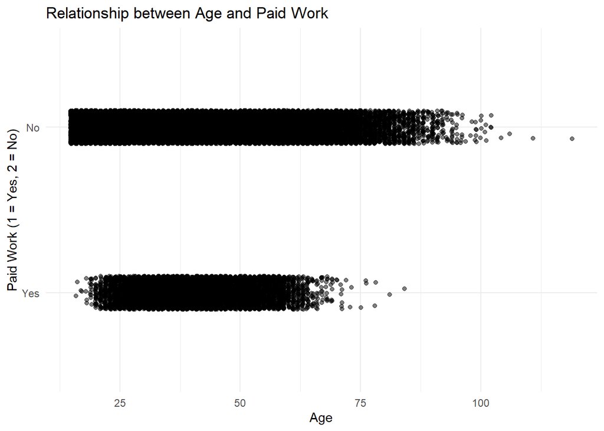

```r
#Load neccesarry packages
library(ggplot2)
library(dplyr)
library(tidyverse)
# Create the plot.
ggplot(data_filtered, aes(x = Q14AGE, y = as.factor(Q24APDWRK))) +
  geom_jitter(width = 0.2, height = 0.1, alpha = 0.5) +
  labs(x = "Age", y = "Paid Work (1 = Yes, 2 = No)",
       title = "Relationship between Age and Paid Work") +
  theme_minimal()
```

### Why the Plot Does Not Work Well Discrete Nature of Paid Work:

-The Paid_work variable is binary (1 for Yes, 2 for No). Plotting this against a continuous variable like age results in a large amount of overplotting, especially when many individuals share the same age.

-Jittering: To make individual points visible, jittering was applied. However, this can sometimes make the plot appear cluttered and less interpretable.

-Limited Variation: If most household members fall into a few age categories or if the majority do not engage in paid work, the plot may not reveal much useful information.

### Alternative Approaches To better understand the relationship, we can consider the following alternative approaches:

-Box Plot or Violin Plot: These can help show the distribution of ages within the groups of those who did and did not do paid work.

-Summarize Data: Create summary statistics or bar plots to show the proportion of individuals engaged in paid work across different age groups.

-Logistic Regression: Perform a logistic regression analysis to quantify the relationship between age and the likelihood of doing paid work.

# b.

```r
library(dplyr)
library(ggplot2)
 # Inspect the column names
colnames(LabourForce)
```

```
## [1] "UQNO"             "Q13GENDER"        "Q14AGE"           "Q15POPULATION"
## [5] "Q16MARITALSTATUS" "Q24APDWRK"        "Education_Status" "Province"
## [9] "Geo_type_code"
```

```r
# Filter data to include only complete cases for the variables of interest and age 15 or older
data_filtered <- LabourForce %>%
  filter(Q14AGE >= 15) %>%
  select(Q13GENDER, Q15POPULATION, Q16MARITALSTATUS, Q24APDWRK, Education_Status, Province, Geo_type_code, Q14AGE) %>%
  na.omit()

# Inspect the first few rows to ensure correct filtering

# Fit a binary logistic regression model
model <- glm(Q24APDWRK ~ Q13GENDER + Q15POPULATION + Q16MARITALSTATUS + Q14AGE + Education_Status  + Province + Geo_type_code,
             data = data_filtered,
             family = binomial ())

# Summary of the model
summary(model)
```

```
##
## Call:
## glm(formula = Q24APDWRK ~ Q13GENDER + Q15POPULATION + Q16MARITALSTATUS +
##     Q14AGE + Education_Status + Province + Geo_type_code, family = binomial(),
##     data = data_filtered)
##
## Coefficients:
##                                              Estimate Std. Error z value
## (Intercept)                                  1.903543   0.147108  12.940
## Q13GENDERFemale                              0.309081   0.027762  11.133
## Q15POPULATIONColoured                        0.039863   0.058696   0.679
## Q15POPULATIONIndian/Asian                    0.318566   0.090888   3.505
## Q15POPULATIONWhite                           0.616904   0.056805  10.860
## Q16MARITALSTATUSLiving together             -0.368157   0.054153  -6.798
## Q16MARITALSTATUSWidow/Widower                1.154962   0.077854  14.835
## Q16MARITALSTATUSDivorced/Separated           0.054343   0.080652   0.674
## Q16MARITALSTATUSNever married                0.572033   0.038882  14.712
## Q14AGE                                      -0.007684   0.001167  -6.586
## Education_StatusLess than primary completed -0.710014   0.126272  -5.623
## Education_StatusPrimary completed           -0.888367   0.135472  -6.558
## Education_StatusSecondary not completed     -1.181793   0.117529 -10.055
## Education_StatusSecondary completed         -1.894077   0.118638 -15.965
## Education_StatusTertiary                    -2.618660   0.121133 -21.618
## Education_StatusOther                       -0.892434   0.208139  -4.288
## ProvinceEastern Cape                         0.349107   0.063727   5.478
## ProvinceNorthern Cape                        0.103029   0.088387   1.166
## ProvinceFree State                           0.263627   0.072143   3.654
## ProvinceKwaZulu-Natal                        0.273864   0.059235   4.623
## ProvinceNorth West                           0.141334   0.077985   1.812
## ProvinceGauteng                              0.347823   0.054004   6.441
## ProvinceMpumalanga                           0.127764   0.068523   1.865
## ProvinceLimpopo                              0.231909   0.070299   3.299
## Geo_type_codeTraditional                     0.675161   0.039709  17.003
## Geo_type_codeFarms                          -0.687054   0.076815  -8.944
##                                             Pr(>|z|)
## (Intercept)                                  < 2e-16 ***
## Q13GENDERFemale                              < 2e-16 ***
## Q15POPULATIONColoured                       0.497047
## Q15POPULATIONIndian/Asian                   0.000457 ***
## Q15POPULATIONWhite                           < 2e-16 ***
```

[output cut: 16 more lines]

```
## ProvinceGauteng                             1.19e-10 ***
## ProvinceMpumalanga                          0.062246 .
## ProvinceLimpopo                             0.000971 ***
## Geo_type_codeTraditional                     < 2e-16 ***
## Geo_type_codeFarms                           < 2e-16 ***
## ---
## Signif. codes:  0 '***' 0.001 '**' 0.01 '*' 0.05 '.' 0.1 ' ' 1
##
## (Dispersion parameter for binomial family taken to be 1)
##
##     Null deviance: 36484  on 31942  degrees of freedom
## Residual deviance: 32328  on 31917  degrees of freedom
## AIC: 32380
##
## Number of Fisher Scoring iterations: 5
```

### Reporting Resudualdevience and degree of fredom

```r
# Extract residual deviance and degrees of freedom
residual_deviance <- model$deviance
degrees_of_freedom <- model$df.residual

# Print the results
cat("Residual Deviance:", residual_deviance, "\n")
```

```
## Residual Deviance: 32328.37
```

```r
cat("Degrees of Freedom:", degrees_of_freedom, "\n")
```

```
## Degrees of Freedom: 31917
```

The residual deviance and associated degrees of freedom can provide insight into the model fit. The residual deviance is a measure of how well the model fits the data; lower values indicate a better fit though in our case we realise that the deviance is higher therefore the is no better fit.However, residual deviance alone is not sufficient to conclude whether the model fits well. It should be complemented with other goodness-of-fit measures, such as:

-AIC (Akaike Information Criterion): A lower AIC indicates a better-fitting model. -Pseudo R-squared: Provides a measure of how well the model explains the variability in the response variable. -Residuals Analysis: Inspecting residuals for patterns or systematic deviations. . The degrees of freedom represent the number of observations minus the number of estimated parameters.

(Assessing Model Fit) To determine if the model fits the data well, we can compare the residual deviance to a chi-squared distribution with the corresponding degrees of freedom. If the residual deviance is significantly higher than the expected chi-squared value, the model may not fit the data well.

Conclusion While residual deviance and degrees of freedom are useful for assessing model fit, they should be part of a broader set of diagnostics and considerations when evaluating the model’s performance.

# c.

```r
 #Perform stepwise model selection using AIC
best_model <- step(model)
```

```
## Start:  AIC=32380.37
## Q24APDWRK ~ Q13GENDER + Q15POPULATION + Q16MARITALSTATUS + Q14AGE +
##     Education_Status + Province + Geo_type_code
##
##                    Df Deviance   AIC
## <none>                   32328 32380
## - Q14AGE            1    32371 32421
## - Province          8    32389 32425
## - Q13GENDER         1    32453 32503
## - Q15POPULATION     3    32458 32504
## - Geo_type_code     2    32772 32820
## - Q16MARITALSTATUS  4    33010 33054
## - Education_Status  6    34087 34127
```

```r
# Summary of the best model
summary(best_model)
```

```
##
## Call:
## glm(formula = Q24APDWRK ~ Q13GENDER + Q15POPULATION + Q16MARITALSTATUS +
##     Q14AGE + Education_Status + Province + Geo_type_code, family = binomial(),
##     data = data_filtered)
##
## Coefficients:
##                                              Estimate Std. Error z value
## (Intercept)                                  1.903543   0.147108  12.940
## Q13GENDERFemale                              0.309081   0.027762  11.133
## Q15POPULATIONColoured                        0.039863   0.058696   0.679
## Q15POPULATIONIndian/Asian                    0.318566   0.090888   3.505
## Q15POPULATIONWhite                           0.616904   0.056805  10.860
## Q16MARITALSTATUSLiving together             -0.368157   0.054153  -6.798
## Q16MARITALSTATUSWidow/Widower                1.154962   0.077854  14.835
## Q16MARITALSTATUSDivorced/Separated           0.054343   0.080652   0.674
## Q16MARITALSTATUSNever married                0.572033   0.038882  14.712
## Q14AGE                                      -0.007684   0.001167  -6.586
## Education_StatusLess than primary completed -0.710014   0.126272  -5.623
## Education_StatusPrimary completed           -0.888367   0.135472  -6.558
## Education_StatusSecondary not completed     -1.181793   0.117529 -10.055
## Education_StatusSecondary completed         -1.894077   0.118638 -15.965
## Education_StatusTertiary                    -2.618660   0.121133 -21.618
## Education_StatusOther                       -0.892434   0.208139  -4.288
## ProvinceEastern Cape                         0.349107   0.063727   5.478
## ProvinceNorthern Cape                        0.103029   0.088387   1.166
## ProvinceFree State                           0.263627   0.072143   3.654
## ProvinceKwaZulu-Natal                        0.273864   0.059235   4.623
## ProvinceNorth West                           0.141334   0.077985   1.812
## ProvinceGauteng                              0.347823   0.054004   6.441
## ProvinceMpumalanga                           0.127764   0.068523   1.865
## ProvinceLimpopo                              0.231909   0.070299   3.299
## Geo_type_codeTraditional                     0.675161   0.039709  17.003
## Geo_type_codeFarms                          -0.687054   0.076815  -8.944
##                                             Pr(>|z|)
## (Intercept)                                  < 2e-16 ***
## Q13GENDERFemale                              < 2e-16 ***
## Q15POPULATIONColoured                       0.497047
## Q15POPULATIONIndian/Asian                   0.000457 ***
## Q15POPULATIONWhite                           < 2e-16 ***
```

[output cut: 16 more lines]

```
## ProvinceGauteng                             1.19e-10 ***
## ProvinceMpumalanga                          0.062246 .
## ProvinceLimpopo                             0.000971 ***
## Geo_type_codeTraditional                     < 2e-16 ***
## Geo_type_codeFarms                           < 2e-16 ***
## ---
## Signif. codes:  0 '***' 0.001 '**' 0.01 '*' 0.05 '.' 0.1 ' ' 1
##
## (Dispersion parameter for binomial family taken to be 1)
##
##     Null deviance: 36484  on 31942  degrees of freedom
## Residual deviance: 32328  on 31917  degrees of freedom
## AIC: 32380
##
## Number of Fisher Scoring iterations: 5
```

```r
residual_deviance_best_model <- best_model$deviance
degrees_of_freedom_best_model <- best_model$df.residual

cat("Residual Deviance of the Best Model:", residual_deviance_best_model, "\n")
```

```
## Residual Deviance of the Best Model: 32328.37
```

```r
cat("Degrees of Freedom of the Best Model:", degrees_of_freedom_best_model, "\n")
```

```
## Degrees of Freedom of the Best Model: 31917
```

```r
cat("AIC of the Best Model:", AIC(best_model), "\n")
```

```
## AIC of the Best Model: 32380.37
```

# d.

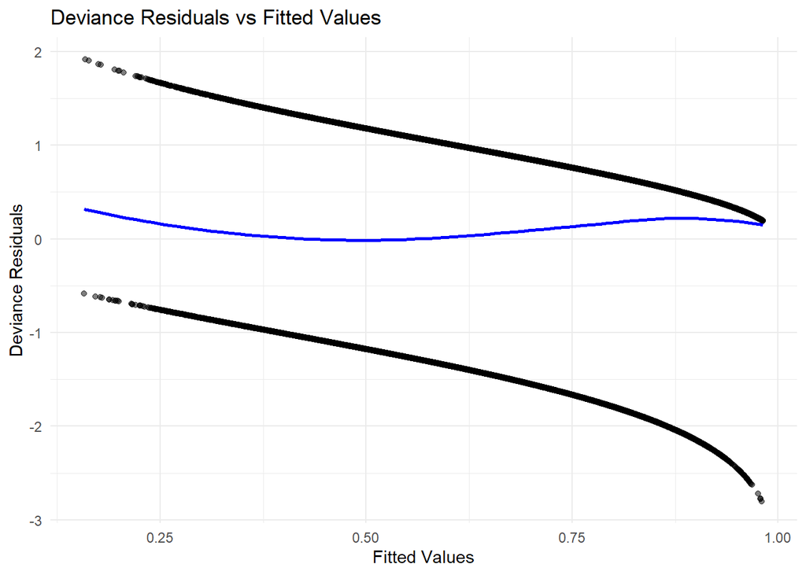

```r
# Calculate the deviance residuals and fitted values
deviance_residuals <- residuals(best_model, type = "deviance")
fitted_values <- fitted(best_model)

# Create a dataframe with deviance residuals and fitted values for plotting
plot_data <- data.frame(DevianceResiduals = deviance_residuals, FittedValues = fitted_values)

# Plot deviance residuals against fitted values
ggplot(plot_data, aes(x = FittedValues, y = DevianceResiduals)) +
  geom_point(alpha = 0.5) +
  geom_smooth(method = "loess", color = "blue", se = FALSE) +
  labs(title = "Deviance Residuals vs Fitted Values",
       x = "Fitted Values",
       y = "Deviance Residuals") +
  theme_minimal()
```

# Interpretation of Deviance Residuals vs. Fitted Values Plot

The plot above shows the deviance residuals against the fitted values from the regression model.

# Comment

The plot, residuals seem to be symmetric around zero, suggesting no severe systematic deviations. The residuals should ideally be symmetrically distributed around zero across the range of fitted values.

Points far from the bulk of the data could be outliers or influential observations. The plot does not show any extreme outliers, which suggests there are no single points unduly influencing the model.

The density of residuals near the extremes might suggest that the model is highly confident about predictions in those regions, which could be checked further.

Additional diagnostic checks, such as checking for heteroscedasticity, multicollinearity, or influential points using other plots or tests, could further validate the model fit. This initial visual inspection of the residual plot does not reveal severe violations of model assumptions, suggesting that the logistic regression model provides a reasonable fit for the data. However, it is always good practice to perform additional diagnostic tests for a comprehensive evaluation.

# e.

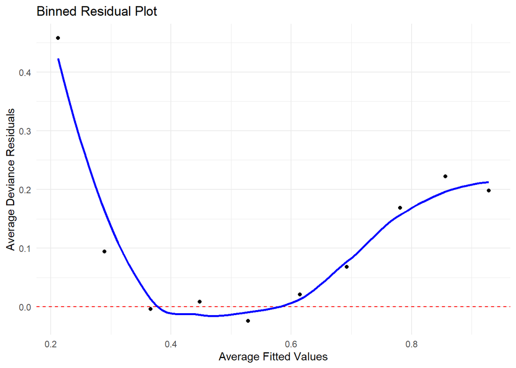

```r
# Load necessary libraries
library(dplyr)
library(ggplot2)

# Function to create binned residuals
binned_residuals <- function(model, bins = 10) {
  # Calculate fitted values and residuals
  fitted_values <- fitted(model)
  residuals <- residuals(model, type = "deviance")

  # Create a data frame with fitted values and residuals
  data <- data.frame(fitted_values, residuals)

  # Create bins and calculate average fitted values and residuals in each bin
  data_binned <- data %>%
    mutate(bin = cut(fitted_values, breaks = bins)) %>%
    group_by(bin) %>%
    summarise(
      avg_fitted = mean(fitted_values),
      avg_residual = mean(residuals)
    )

  return(data_binned)
}

# Create binned residuals
binned_residuals <- binned_residuals(best_model, bins = 10)

# Plot the binned residuals
ggplot(binned_residuals, aes(x = avg_fitted, y = avg_residual)) +
  geom_point() +
  geom_hline(yintercept = 0, linetype = "dashed", color = "red") +
  geom_smooth(method = "loess", se = FALSE, color = "blue") +
  labs(title = "Binned Residual Plot",
       x = "Average Fitted Values",
       y = "Average Deviance Residuals") +
  theme_minimal()
```

# Interpretation of the Binned Residual Plot

The above binned residual plot shows the average deviance residuals against the average fitted values. This type of plot helps in assessing the goodness-of-fit of the model by highlighting any systematic patterns in the residuals.

Average Devience Residuals: The y-axis represents the average deviance residuals within each bin of fitted values. Ideally, these should be close to zero if the model fits well.

Average Fitted Values: The x-axis represents the average predicted probabilities (fitted values) for each bin.

Blue Line (Loess Smoother): The blue line represents a local regression (loess) smoother that shows the general trend of the residuals across the fitted values.Ideally, this line should be flat around zero if the model is well-fitted, which in our case is not clearly flat and that is indication that the model is not well-fitted.

Red Line (Zero Line): The red dashed line represents zero on the y-axis, which serves as a reference for evaluating the residuals.

# Interpretation

Pattern in Residuals: There is a clear pattern in the residuals, with high average residuals at both low and high fitted values, and lower residuals around the middle range of fitted values. This suggests that the model may not be capturing some aspects of the data well, particularly at the extremes.

U-shaped Pattern: The U-shaped pattern suggests a potential issue with the model, such as missing interactions or non-linear relationships between predictors and the response variable.

In conclusion the clear pattern and deviation from zero in the residuals suggest that the model may not be fully capturing the underlying structure of the data. The U-shaped pattern implies that there might be non-linear relationships or interactions between the predictors that the model has not accounted for.

We sholud consider including interaction terms or exploring non-linear relationships in the model. Additional diagnostics, such as checking for multicollinearity or re-evaluating the model specification, might be necessary to improve the fit.

The binned residual plot indicates that there is room for improving the model, especially in how it handles the tails of the distribution of the fitted values.

# f.

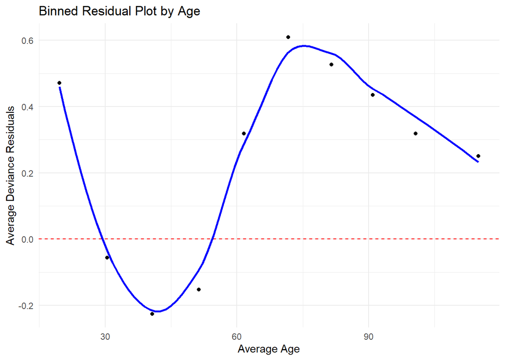

```r
# Function to create binned residuals by age
binned_residuals_age <- function(model, age_variable, bins = 10) {
  # Calculate fitted values and residuals
  fitted_values <- fitted(model)
  residuals <- residuals(model, type = "deviance")

  # Create a data frame with age, fitted values, and residuals
  data <- data.frame(age_variable, fitted_values, residuals)

  # Create bins and calculate average age and residuals in each bin
  data_binned <- data %>%
    mutate(bin = cut(age_variable, breaks = bins)) %>%
    group_by(bin) %>%
    summarise(
      avg_age = mean(age_variable),
      avg_residual = mean(residuals)
    )

  return(data_binned)
}

# Create binned residuals by age
binned_residuals_age <- binned_residuals_age(best_model, data_filtered$Q14AGE, bins = 10)

# Plot the binned residuals by age
ggplot(binned_residuals_age, aes(x = avg_age, y = avg_residual)) +
  geom_point() +
  geom_hline(yintercept = 0, linetype = "dashed", color = "red") +
  geom_smooth(method = "loess", se = FALSE, color = "blue") +
  labs(title = "Binned Residual Plot by Age",
       x = "Average Age",
       y = "Average Deviance Residuals") +
  theme_minimal()
```

# Interpretation of the Binned Residual Plot by Age

The binned residual plot by age shows the average deviance residuals against the average age. This plot helps in identifying whether the model’s fit varies across different age groups.

Average Deviance Residuals: The y-axis represents the average deviance residuals within each bin of age. Ideally, these residuals should be centered around zero if the model fits well across all age groups.

Average Age: The x-axis represents the average age within each bin.

Blue Line (Loess Smoother): The blue line represents a local regression (loess) smoother that shows the general trend of the residuals across different age groups. Ideally, this line should be close to the zero line, indicating no systematic lack of fit.

Red Line (Zero Line): The red dashed line represents zero on the y-axis, serving as a reference for evaluating the residuals.

Non-linear Relationship: The curved pattern suggests a non-linear relationship between age and the response variable (Paid work) that is not fully captured by the model.The dip and rise indicate that the effect of age on the likelihood of being in paid work is more complex than the model accounts for.

In conclusion the pattern in the residuals indicates that the model does not fit equally well across all age groups.The significant deviations from zero suggest that the relationship between age and paid work is not fully linear or is not adequately modeled by the current predictors.

We sholud consider including polynomial terms for age or age interactions with other variables to better capture the non-linear relationship.Reevaluate the model specification to account for potential age-related effects that are currently not modeled.

The binned residual plot by age highlights areas where the model could be improved to better fit the data, particularly by addressing the non-linear relationship between age and the likelihood of being in paid work.

# g.

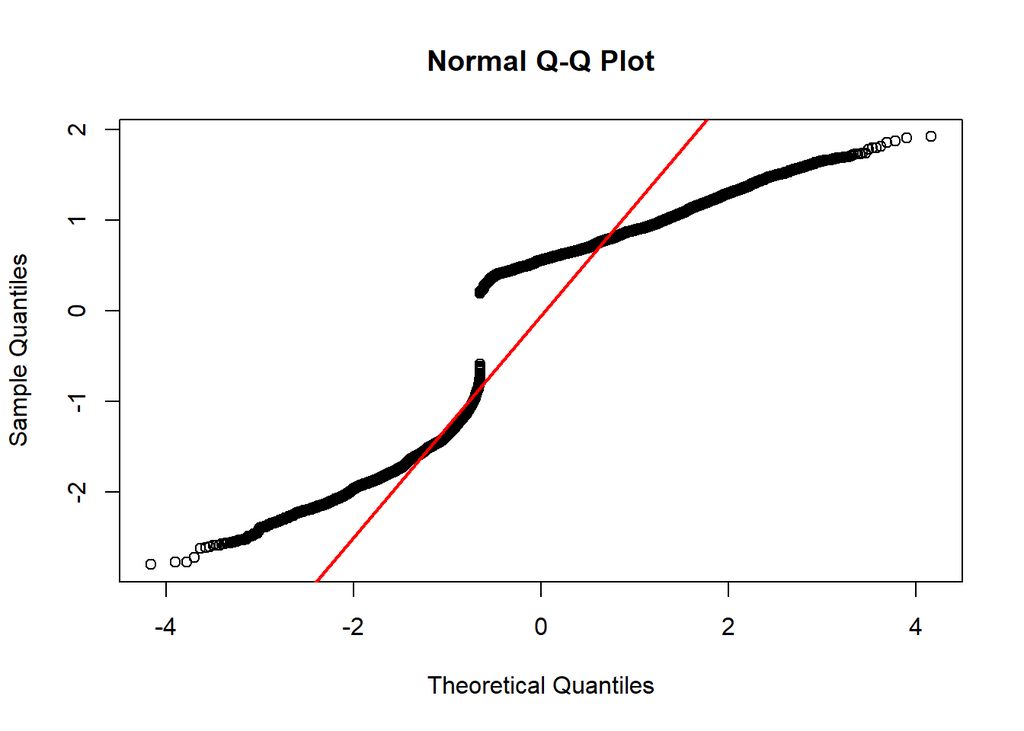

```r
# Extract deviance residuals from the best model
deviance_residuals <- residuals(best_model, type = "deviance")

# Create a QQ plot
qqnorm(deviance_residuals)
qqline(deviance_residuals, col = "red", lwd = 2)
```

# Interpretation of the Normal Q-Q Plot

Theoretical Quantiles:

The x-axis represents the theoretical quantiles from a standard normal distribution (expected values if the data were normally distributed). Sample Quantiles:

The y-axis represents the actual quantiles of the residuals from your model.

The red line is the reference line where the points would fall if the residuals were perfectly normally distributed. If the residuals are normally distributed, the points should lie approximately along this line.

# Interpretation

Points that closely follow the red line suggest that the residuals are approximately normally distributed.Significant deviations from the line indicate departures from normality.

The plot shows clear deviations from the red line, especially at the tails (both ends of the distribution).The points at the lower end (left side) and upper end (right side) of the plot deviate significantly from the red line.

This departure from normality may affect the validity of inference (e.g., confidence intervals, hypothesis tests) that rely on the normality assumption. It’s important to check other model assumptions and consider potential transformations or different modeling approaches to address non-normality.

In conclusion the Normal Q-Q plot indicates that the residuals are not normally distributed, suggesting that the model might need adjustments or alternative approaches to better fit the data and meet the assumptions of normality.